# EDAV Problem Set 4 Fall 2025

## 5. Partial Dependence Plots

1. Use the **pdp** with **ggplot2** to create faceted graphs showing the partial dependence plots for the numeric variables in `bigtree` and `forest`. For each, the facets should be in *decreasing order* of standard deviation for `yhat`.

Note: Use the parameter `prob = TRUE` with `partial()` so the predictions will be probabilities.

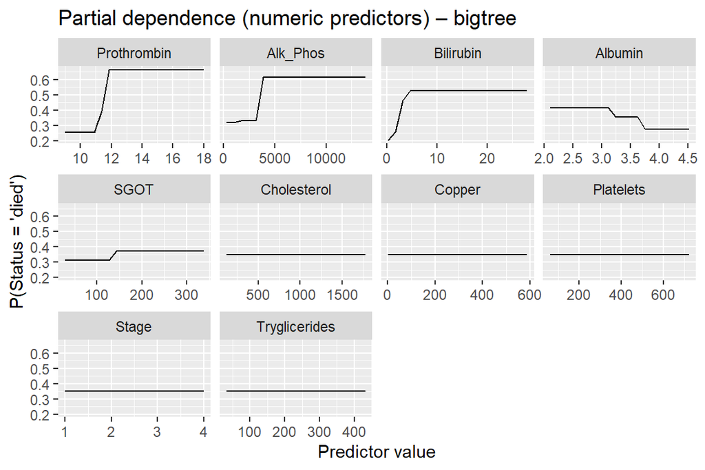

```r
library(dplyr)
library(purrr)
library(forcats)
library(ggplot2)
library(pdp)

## Helper: one-variable PDP in long format --------------------------
get_pdp_long <- function(model, train_dat, var) {
  pd <- partial(
    object  = model,
    pred.var = var,
    train   = train_dat,
    prob    = TRUE,          # probability scale
    which.class = "died",    # P(Status = "died")
    plot    = FALSE,
    grid.resolution = 20
  )

  tibble(
    variable = var,
    value    = pd[[var]],
    yhat     = pd$yhat       # <- this is the correct column name
  )
}

## ---------- bigtree PDPs (numeric predictors only) ----------------

num_vars_big <- df_train |>
  select(-Status) |>
  select(where(is.numeric)) |>
  names()

pdp_big_long <- map_dfr(
  num_vars_big,
  get_pdp_long,
  model = bigtree,
  train_dat = df_train
)

# order facets by decreasing sd(yhat)
sd_big <- pdp_big_long |>
  group_by(variable) |>
  summarise(sd_yhat = sd(yhat), .groups = "drop")

pdp_big_long <- pdp_big_long |>
  left_join(sd_big, by = "variable") |>
  mutate(variable = fct_reorder(variable, sd_yhat, .desc = TRUE))

ggplot(pdp_big_long, aes(x = value, y = yhat)) +
  geom_line() +
  facet_wrap(~ variable, scales = "free_x") +
  labs(
    x = "Predictor value",
    y = "P(Status = 'died')",
    title = "Partial dependence (numeric predictors) – bigtree"
  )
```

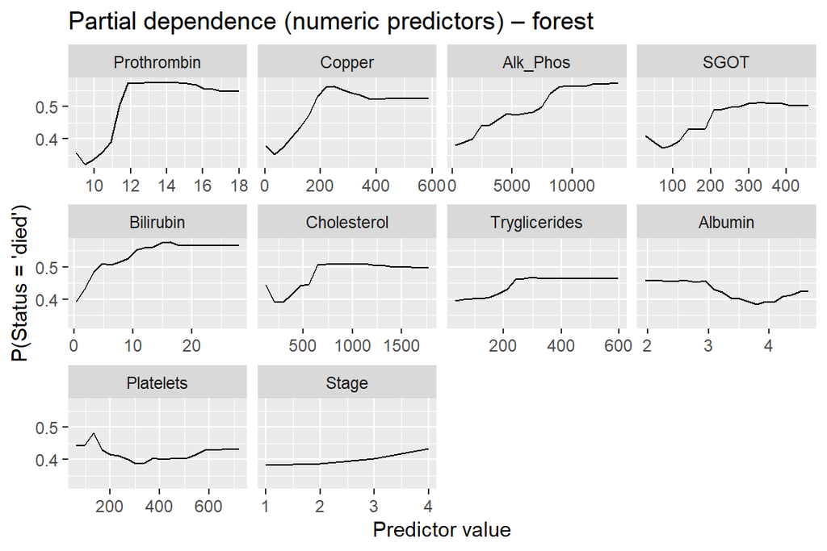

```r
## ---------- forest PDPs -------------------------------------------

num_vars_for <- forest_train |>
  select(-Status) |>
  select(where(is.numeric)) |>
  names()

pdp_for_long <- map_dfr(
  num_vars_for,
  get_pdp_long,
  model = forest,
  train_dat = forest_train
)

sd_for <- pdp_for_long |>
  group_by(variable) |>
  summarise(sd_yhat = sd(yhat), .groups = "drop")

pdp_for_long <- pdp_for_long |>
  left_join(sd_for, by = "variable") |>
  mutate(variable = fct_reorder(variable, sd_yhat, .desc = TRUE))

ggplot(pdp_for_long, aes(x = value, y = yhat)) +
  geom_line() +
  facet_wrap(~ variable, scales = "free_x") +
  labs(
    x = "Predictor value",
    y = "P(Status = 'died')",
    title = "Partial dependence (numeric predictors) – forest"
  )
```

2. Describe the similarities and differences in pdp plots within each and across the models.

In bigtree, the PDPs are step-like and only a few variables (like Prothrombin, Alk_Phos, Bilirubin, Albumin) actually move the predicted death probability, while the rest are basically flat. In the random forest, almost every numeric variable shows a smoother change in risk as the predictor changes. Across the two, both agree that higher Bilirubin/Prothrombin/Alk_Phos and lower Albumin mean higher risk of death, but the forest spreads the signal over more variables and in a less jumpy way.

## 6. LIME

1. Use LIME to explain the prediction `forest` makes for the `forest_test` observation. What is the linear equation it produces? (Use 4 features and don’t change any defaults.)

```r
library(lime)

# Tell lime how to handle randomForest models
model_type.randomForest <- function(x, ...) {
  "classification"
}

predict_model.randomForest <- function(x, newdata, ...) {
  as.data.frame(
    predict(x, newdata = newdata, type = "prob")
  )
}

# Data for LIME (drop the response)
x_forest_train <- forest_train |> dplyr::select(-Status)
x_forest_test  <- forest_test  |> dplyr::select(-Status)

# Build LIME explainer and explain the single test case
forest_explainer <- lime(
  x     = x_forest_train,
  model = forest
)

forest_expl <- explain(
  x          = x_forest_test,
  explainer  = forest_explainer,
  n_features = 4,   # 4 features as requested
  n_labels   = 1    # explain the predicted class
)

forest_expl
```

```
# A tibble: 4 × 13
  model_type    case  label label_prob model_r2 model_intercept model_prediction
  <chr>         <chr> <chr>      <dbl>    <dbl>           <dbl>            <dbl>
1 classificati… 125   surv…      0.824    0.125           0.386            0.682
2 classificati… 125   surv…      0.824    0.125           0.386            0.682
3 classificati… 125   surv…      0.824    0.125           0.386            0.682
4 classificati… 125   surv…      0.824    0.125           0.386            0.682
# ℹ 6 more variables: feature <chr>, feature_value <dbl>, feature_weight <dbl>,
#   feature_desc <chr>, data <list>, prediction <list>
```

```r
# Extract intercept and coefficients for the linear equation
exp_row   <- forest_expl
intercept <- unique(exp_row$model_intercept)

coefs <- exp_row |>
  dplyr::select(feature, feature_weight)

intercept
```

```
[1] 0.3863905
```

```r
coefs
```

```
# A tibble: 4 × 2
  feature     feature_weight
  <chr>                <dbl>
1 Prothrombin         0.0809
2 Ascites             0.125
3 Bilirubin           0.0463
4 Alk_Phos            0.0434
```

```r
# forest_expl already created above

# Intercept and label being explained
intercept <- unique(forest_expl$model_intercept)
label     <- unique(forest_expl$label)

# Check that LIME decomposition matches its own prediction
approx_pred <- intercept + sum(forest_expl$feature_weight)
approx_pred
```

```
[1] 0.6820488
```

```r
forest_expl$model_prediction[1]
```

```
[1] 0.6820488
```

```r
# Build a human-readable equation string
terms <- sprintf(
  "%+0.3f (%s)",
  forest_expl$feature_weight,
  forest_expl$feature
)

equation <- paste0(
  "P(Status = '", label, "') ≈ ",
  sprintf("%0.3f", intercept), " ",
  paste(terms, collapse = " ")
)

equation
```

```
[1] "P(Status = 'survived') ≈ 0.386 +0.081 (Prothrombin) +0.125 (Ascites) +0.046 (Bilirubin) +0.043 (Alk_Phos)"
```

2. What is the $r^2$ for the LIME model?

Already given from my calculations in the last question, it is 0.125.

3. Recreate a LIME model for the same test observation several times. Do the results (explanation fit, feature selection, feature weights) vary?

```r
#| warning: false
#| message: false

library(dplyr)
library(purrr)
library(ggplot2)
library(lime)

# Seeds for repeated LIME runs
seeds <- 1:5

# Run LIME multiple times on the same test observation
lime_list <- lapply(seeds, function(s) {
  set.seed(s)
  explain(
    x          = x_forest_test,
    explainer  = forest_explainer,
    n_features = 4,
    n_labels   = 1
  ) |>
    mutate(run = s)
})

# Combine to inspect variation in features / weights / r2
lime_runs <- bind_rows(lime_list)

lime_runs %>%
  select(run, feature, feature_weight, model_r2)
```

```
# A tibble: 20 × 4
     run feature     feature_weight model_r2
   <int> <chr>                <dbl>    <dbl>
 1     1 Prothrombin         0.0802    0.117
 2     1 Ascites             0.119     0.117
 3     1 Bilirubin           0.0434    0.117
 4     1 Alk_Phos            0.0366    0.117
 5     2 Prothrombin         0.0771    0.111
 6     2 Ascites             0.117     0.111
 7     2 Bilirubin           0.0377    0.111
 8     2 Alk_Phos            0.0361    0.111
 9     3 Prothrombin         0.0875    0.133
10     3 Ascites             0.131     0.133
11     3 Alk_Phos            0.0425    0.133
12     3 Bilirubin           0.0387    0.133
13     4 Prothrombin         0.0746    0.112
14     4 Ascites             0.120     0.112
15     4 Edema               0.0521    0.112
16     4 Alk_Phos            0.0404    0.112
17     5 Prothrombin         0.0800    0.125
18     5 Ascites             0.126     0.125
19     5 Bilirubin           0.0456    0.125
20     5 Edema               0.0459    0.125
```

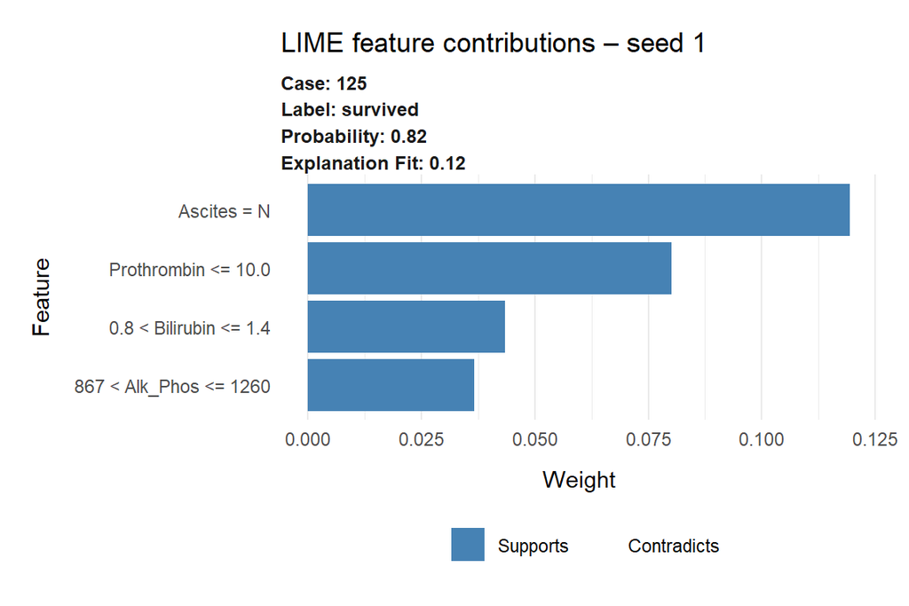

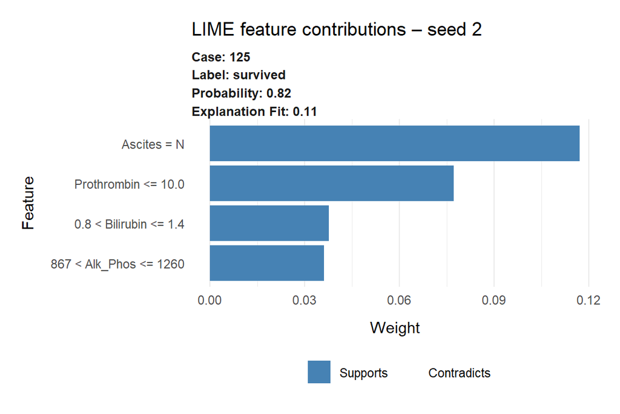

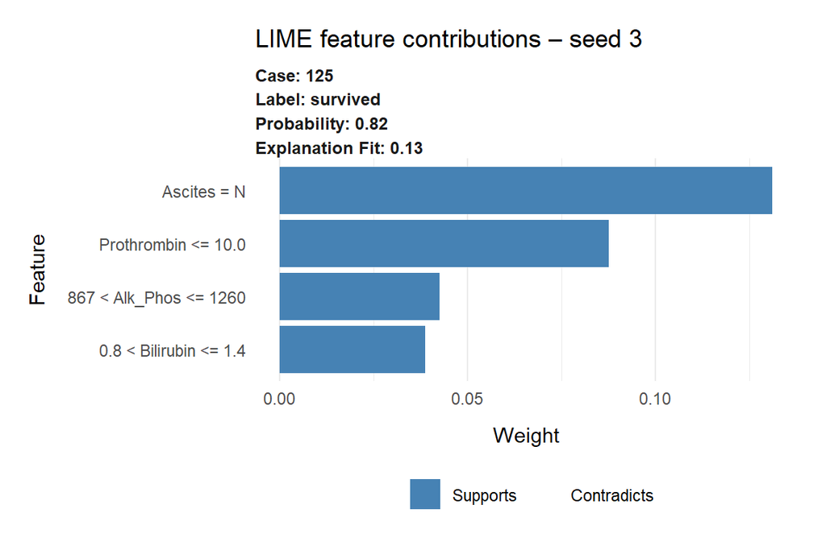

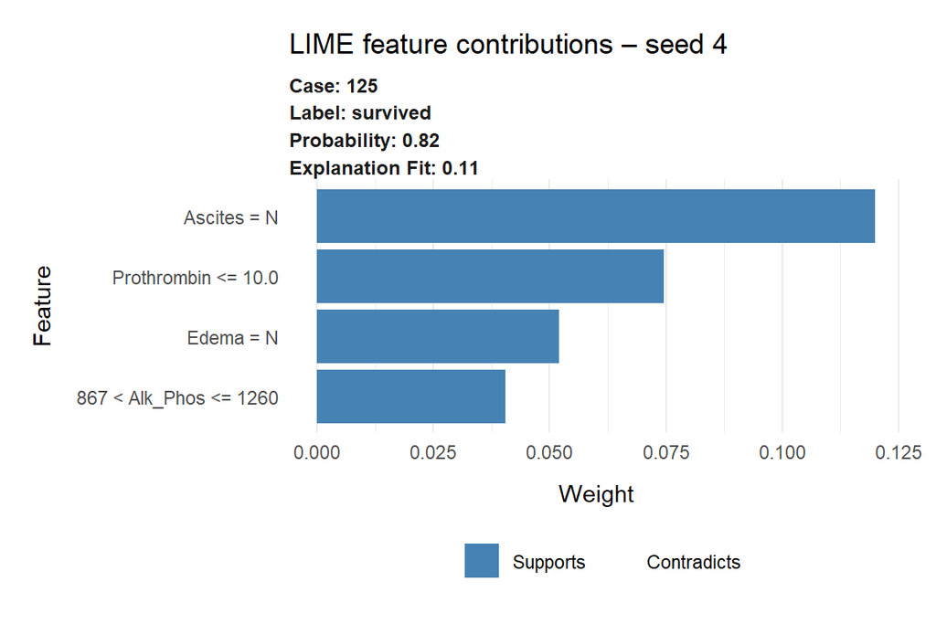

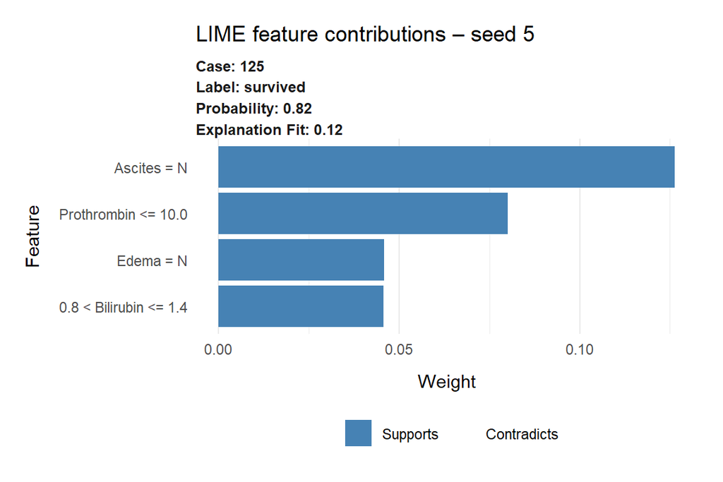

```r
# Plot feature contributions (horizontal bars) for each run
for (i in seq_along(lime_list)) {
  print(
    plot_features(lime_list[[i]]) +
      ggtitle(paste("LIME feature contributions – seed", seeds[i]))
  )
}
```

```r
library(forcats)

# Summarize how stable each feature is across runs
lime_summary <- lime_runs |>
  group_by(feature) |>
  summarise(
    mean_weight = mean(feature_weight),
    sd_weight = sd(feature_weight),
    times_selected = n(),
    .groups = "drop"
  )

lime_summary
```

```
# A tibble: 5 × 4
  feature     mean_weight sd_weight times_selected
  <chr>             <dbl>     <dbl>          <int>
1 Alk_Phos         0.0389   0.00307              4
2 Ascites          0.123    0.00575              5
3 Bilirubin        0.0414   0.00378              4
4 Edema            0.0490   0.00436              2
5 Prothrombin      0.0799   0.00484              5
```

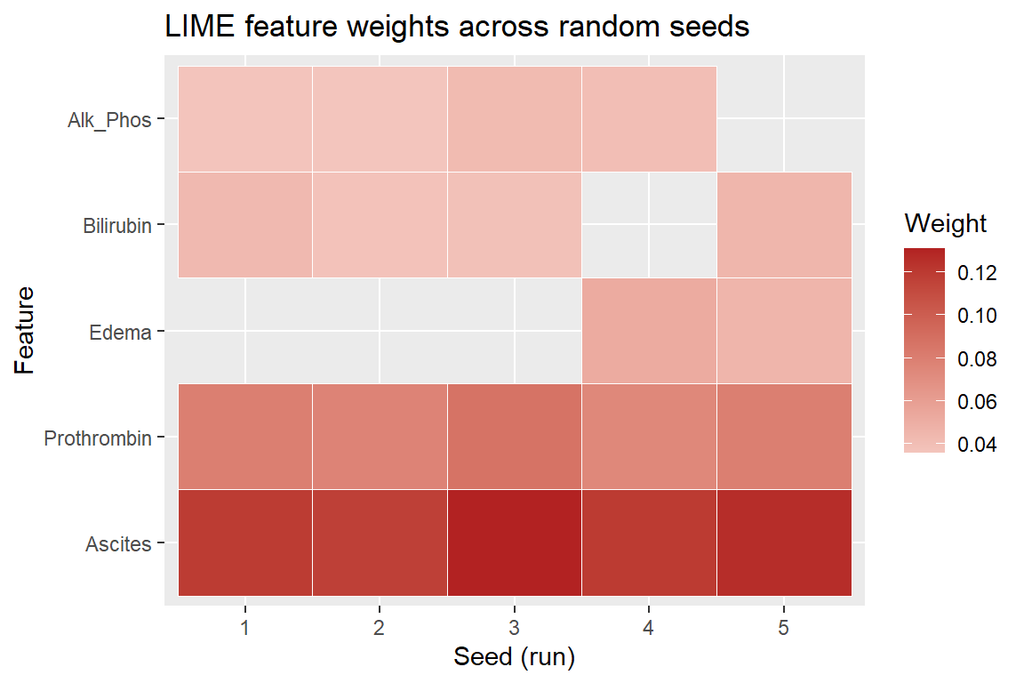

```r
# Make a "cute" heatmap of feature weights across runs
lime_runs_plot <- lime_runs |>
  mutate(
    run = factor(run),
    feature = fct_reorder(feature, feature_weight,
                          .fun = mean, .desc = TRUE)
  )

ggplot(lime_runs_plot,
       aes(x = run, y = feature, fill = feature_weight)) +
  geom_tile(color = "white") +
  scale_fill_gradient2(
    low = "steelblue",
    mid = "white",
    high = "firebrick",
    midpoint = 0
  ) +
  labs(
    title = "LIME feature weights across random seeds",
    x = "Seed (run)",
    y = "Feature",
    fill = "Weight"
  )
```

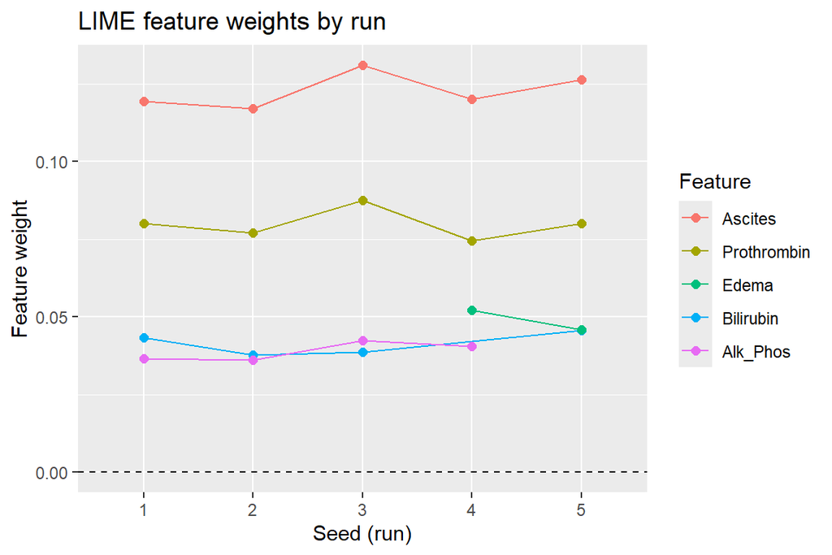

```r
# Line/point plot to show how each feature's weight changes by run
ggplot(lime_runs_plot,
       aes(x = run, y = feature_weight, group = feature,
           color = feature)) +
  geom_hline(yintercept = 0, linetype = "dashed") +
  geom_line() +
  geom_point(size = 2) +
  labs(
    title = "LIME feature weights by run",
    x = "Seed (run)",
    y = "Feature weight"
  ) +
  guides(color = guide_legend(title = "Feature"))
```

4. Repeat part c) adding `n_permutations = 50`. What are the results now?

```r
#| warning: false
#| message: false

library(dplyr)
library(purrr)
library(ggplot2)
library(lime)

# Same seeds as before
seeds <- 1:5

# Run LIME multiple times with n_permutations = 50
lime_list_50 <- lapply(seeds, function(s) {
  set.seed(s)
  explain(
    x              = x_forest_test,
    explainer      = forest_explainer,
    n_features     = 4,
    n_labels       = 1,
    n_permutations = 50
  ) |>
    mutate(run = s)
})

# Combine so you can look at variation
lime_runs_50 <- bind_rows(lime_list_50)

lime_runs_50 %>%
  select(run, feature, feature_weight, model_r2)
```

```
# A tibble: 20 × 4
     run feature       feature_weight model_r2
   <int> <chr>                  <dbl>    <dbl>
 1     1 Ascites               0.168     0.350
 2     1 Albumin               0.0745    0.350
 3     1 Drug                  0.0559    0.350
 4     1 Hepatomegaly         -0.0576    0.350
 5     2 Ascites               0.200     0.304
 6     2 Drug                 -0.0714    0.304
 7     2 Alk_Phos              0.0683    0.304
 8     2 Cholesterol           0.0556    0.304
 9     3 Bilirubin             0.0700    0.283
10     3 Prothrombin           0.0812    0.283
11     3 Albumin               0.0740    0.283
12     3 Edema                 0.0861    0.283
13     4 Prothrombin           0.0781    0.268
14     4 Tryglicerides        -0.0732    0.268
15     4 Platelets             0.0496    0.268
16     4 Ascites               0.0833    0.268
17     5 Prothrombin           0.111     0.356
18     5 Bilirubin             0.108     0.356
19     5 SGOT                 -0.0786    0.356
20     5 Stage                -0.0677    0.356
```

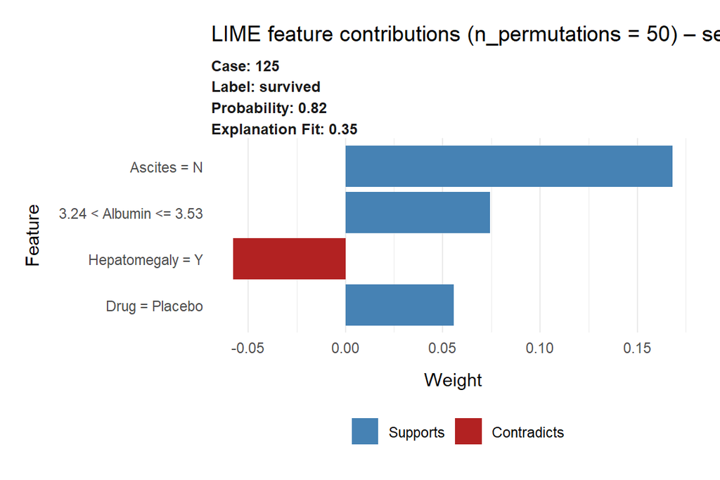

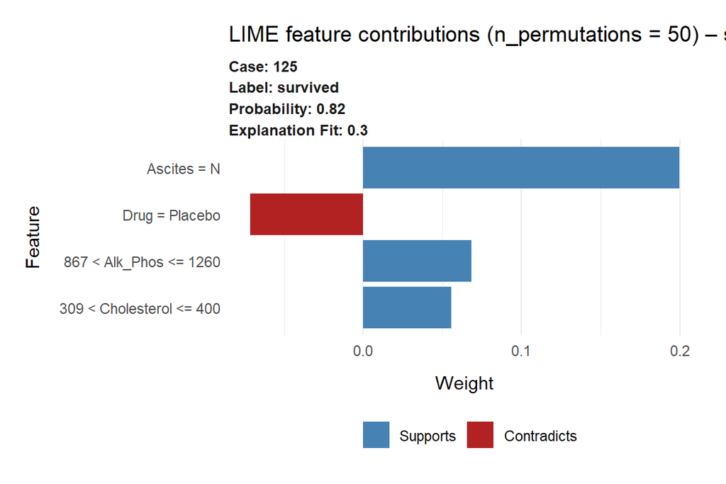

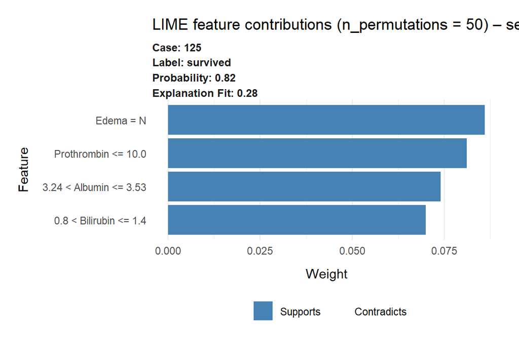

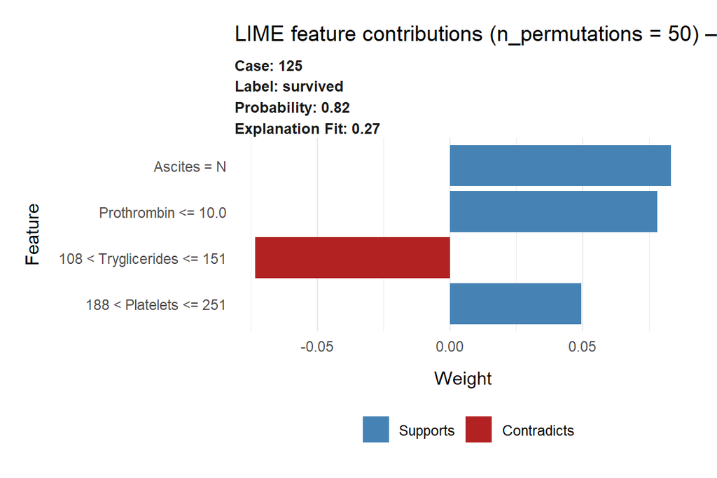

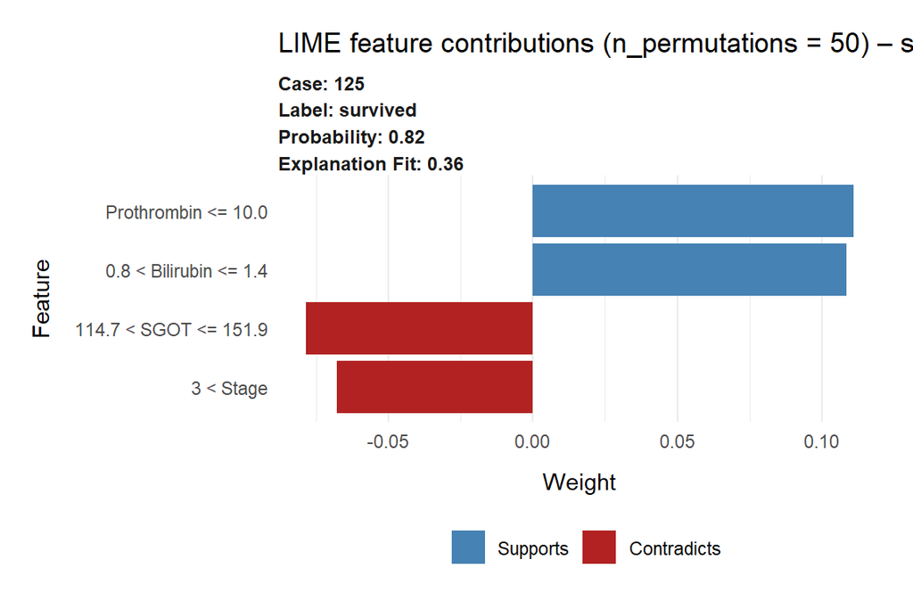

```r
# Plot feature contributions for each run (horizontal bar plots)
for (i in seq_along(lime_list_50)) {
  print(
    plot_features(lime_list_50[[i]]) +
      ggtitle(paste("LIME feature contributions (n_permutations = 50) – seed", seeds[i]))
  )
}
```

```r
library(forcats)

# Summarize stability of features with n_permutations = 50
lime_summary_50 <- lime_runs_50 |>
  group_by(feature) |>
  summarise(
    mean_weight    = mean(feature_weight),
    sd_weight      = sd(feature_weight),
    times_selected = n(),
    .groups = "drop"
  )

lime_summary_50
```

```
# A tibble: 13 × 4
   feature       mean_weight sd_weight times_selected
   <chr>               <dbl>     <dbl>          <int>
 1 Albumin           0.0742   0.000316              2
 2 Alk_Phos          0.0683  NA                     1
 3 Ascites           0.150    0.0602                3
 4 Bilirubin         0.0892   0.0271                2
 5 Cholesterol       0.0556  NA                     1
 6 Drug             -0.00777  0.0900                2
 7 Edema             0.0861  NA                     1
 8 Hepatomegaly     -0.0576  NA                     1
 9 Platelets         0.0496  NA                     1
10 Prothrombin       0.0901   0.0182                3
11 SGOT             -0.0786  NA                     1
12 Stage            -0.0677  NA                     1
13 Tryglicerides    -0.0732  NA                     1
```

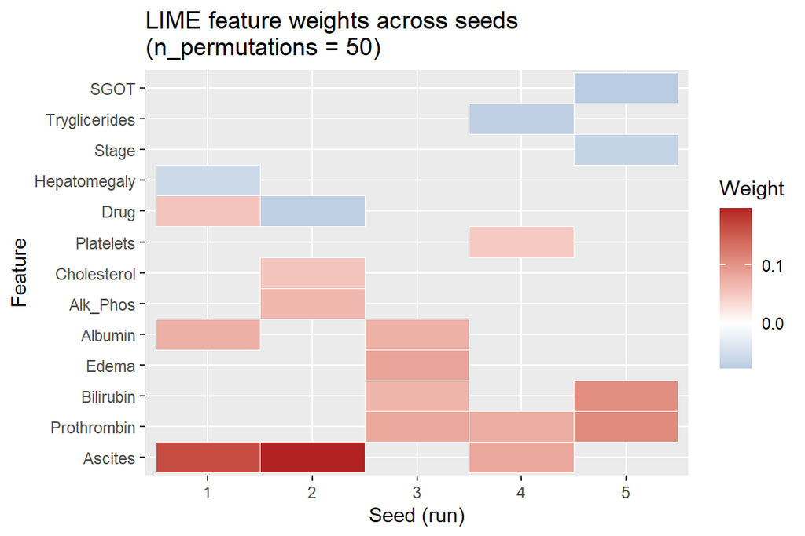

```r
# Heatmap of feature weights across runs (n_permutations = 50)
lime_runs_50_plot <- lime_runs_50 |>
  mutate(
    run = factor(run),
    feature = fct_reorder(
      feature, feature_weight,
      .fun = mean, .desc = TRUE
    )
  )

ggplot(lime_runs_50_plot,
       aes(x = run, y = feature, fill = feature_weight)) +
  geom_tile(color = "white") +
  scale_fill_gradient2(
    low = "steelblue",
    mid = "white",
    high = "firebrick",
    midpoint = 0
  ) +
  labs(
    title = "LIME feature weights across seeds\n(n_permutations = 50)",
    x = "Seed (run)",
    y = "Feature",
    fill = "Weight"
  )
```

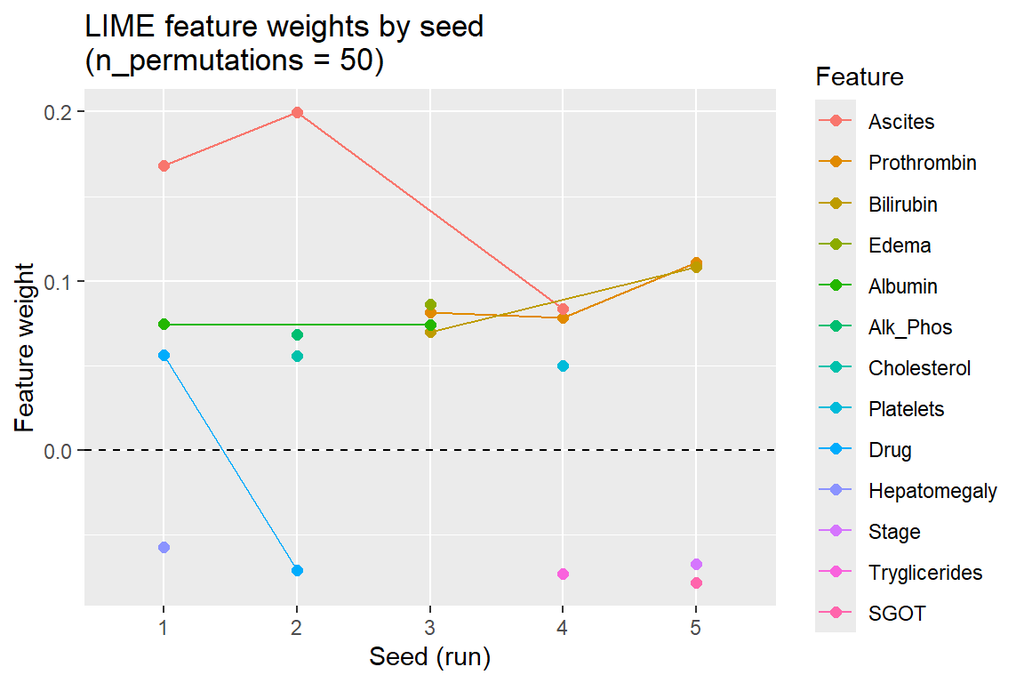

```r
# Line/point plot of weights by run (n_permutations = 50)
ggplot(lime_runs_50_plot,
       aes(x = run, y = feature_weight,
           group = feature, color = feature)) +
  geom_hline(yintercept = 0, linetype = "dashed") +
  geom_line() +
  geom_point(size = 2) +
  labs(
    title = "LIME feature weights by seed\n(n_permutations = 50)",
    x = "Seed (run)",
    y = "Feature weight"
  ) +
  guides(color = guide_legend(title = "Feature"))
```

It is clear from outputted graphs that variation is larger and that some features now have negative weights associated with them.